# Pinterest API Tutorial

*Nome*: Maria Natasha  
*Cognome*: Fragalà  
*Matricola*: 100084481  
*Corso*: Social Media Data Analysis  
*Docente*: Francesco Ragusa  
*Anno Accademico*: 2024–2025

L’**API di Pinterest** consente la creazione di applicazioni in grado di interagire con il servizio di Pinterest, ad esempio il recupero di dati su **Pin** e **Board**, la **creazione e gestione dei profili utente**, di **contenuti**, l’**analisi delle performance dei Pin** o l'**automazione delle campagne pubblicitarie**.

### Indice:

- Introduzione
- Profilo e Applicazione
- Configurazione dell'Ambiente e Interazione con l'API
1. Token di produzione limitata
2. Token sandbox
3. OAuth 2.0
- Visualizzazione e interpretazione dei dati
- Conclusioni
- Referenze

### Introduzione

Pinterest è una piattaforma di **condivisione** di **immagini** e **video** che funge da fonte di ispirazione per milioni di utenti in tutto il mondo. Fondata nel **2010** da **Ben Silbermann**, **Paul Sciarra** e **Evan Sharp**, questa piattaforma consente agli utenti di scoprire, salvare e condividere idee attraverso **"Pin"**.

Gli utenti di Pinterest possono caricare vari **contenuti multimediali**, come immagini e video, aggiungendo titoli, descrizioni e link esterni per fornire ulteriori dettagli o rimandare a contenuti correlati. I **Pin**, per facilitare la categorizzazione e la gestione delle raccolte di contenuti, possono essere organizzati in **Board tematiche**; queste ultime possono essere **collaborative**, permettendo a più utenti di contribuire con i propri Pin su un determinato tema.  
Questa [struttura](https://developers.pinterest.com/docs/getting-started/pinterest-entities/) agevola la ricerca e la scoperta di idee su una **vasta gamma di argomenti**, come fitness, moda, tecnologia e molto altro. Inoltre, seguendo altri profili o specifiche board, gli utenti possono rimanere aggiornati sulle ultime aggiunte e trarre ulteriore ispirazione.

[figure not shown]

*User account — Image source: Pinterest*

##### **Panoramica delle API di Pinterest:**

Le **API di Pinterest** sono strumenti che permettono agli sviluppatori di interagire con la piattaforma, consentendo l'accesso al vasto database di contenuti di Pinterest, facilitando la gestione dei **"Pin"** e delle **"Board"**, l'analisi delle performance dei contenuti e l'automazione delle campagne pubblicitarie. Tuttavia, è importante notare che le **API v3 e gli endpoint Ads/v4** sono completamente obsoleti, dal **30 giugno 2024**. Per garantire l'accesso alle funzionalità più recenti e ottimizzate, tutte le app devono possedere **API versione 5**, che offre le migliori performance e supporto per le nuove funzionalità della piattaforma. Questo aggiornamento permette agli sviluppatori di concentrarsi sull'innovazione e sulla creazione di esperienze utente coinvolgenti senza dover costruire da zero le funzionalità offerte da Pinterest.  
Esistono **tre metodi principali** per accedere alle API di Pinterest, e in questo tutorial li vedremo *passo dopo passo*, con esempi pratici e spiegazioni dettagliate. Terremo come punto di riferimento la [documentazione di Pinterest](https://developers.pinterest.com/) per garantire che ogni procedura sia allineata alle linee guida ufficiali.

##### **Anteprima dei prossimi passaggi:**

Nei prossimi passaggi del tutorial, esploreremo in **dettaglio** le varie fasi necessarie per creare l’applicazione utilizzando le API di Pinterest. Inizieremo con la creazione di un **account developers** e alla **registrazione dell’applicazione**. Successivamente, **accederemo alle API** e impareremo come utilizzare le chiamate RESTful per ottenere informazioni sui "Pin" e sulle "Board".

### Profilo e Applicazione

Prima di iniziare, assicurati di avere:

Una buona **conoscenza** del linguaggio di programmazione: *Python*.

Per utilizzare le API di Pinterest, è necessario disporre di un **account aziendale.** Gli account aziendali offrono funzionalità aggiuntive, come l'accesso alle analisi e agli strumenti per sviluppatori, che non sono disponibili per gli account personali.

[figure not shown]

##### **Passaggi per creare un account aziendale su Pinterest:**

**1. Registrazione**: Se non hai ancora un **account Pinterest**, visita il sito: [www.pinterest.com](https://it.pinterest.com/) e iscriviti utilizzando il **tuo indirizzo email**.

[figure not shown]

**2. Conversione in account aziendale**: Dopo aver effettuato l'accesso, vai su [settings](https://it.pinterest.com/settings/account-settings/) e segui le istruzioni per convertire il tuo account personale in un account aziendale.

[figure not shown]

**In alternativa**, puoi creare direttamente un nuovo account aziendale visitando [questo sito](https://business.pinterest.com/it/) e cliccando su [Iscriviti](https://business.pinterest.com/it/).

[figure not shown]

*Per ulteriori dettagli sulla configurazione dell'account developer, puoi consultare la [guida ufficiale](https://policy.pinterest.com/it/developer-guidelines.) di Pinterest.*

### Configurazione dell'Ambiente e Interazione con l'API

##### **API REST di Pinterest 5.15.0**

L'accesso all’API di Pinterest può essere utilizzato per:

1. **Monitoraggio delle conversioni:** inviare conversioni.
2. **Gestione dei contenuti:** visualizza, modifica, elimina Pin e bacheche.
3. **Gestione degli annunci:** visualizza, modifica, elimina campagne, gruppi di annunci e annunci.
4. **Targeting:** visualizza, modifica, elimina elenchi di clienti, segmenti di pubblico e altre opzioni di targeting.
5. **Gestione degli acquisti:** visualizza, modifica, elimina feed di catalogo e gruppi di prodotti.
6. **Analisi e reportistica:** richiedi analisi per i tuoi Pin, annunci, gruppi di annunci, campagne o account

*Per ulteriori dettagli qui troverai informazioni su tutti gli endpoint disponibili nella Pinterest API: [approfondisci qui!](https://developers.pinterest.com/docs/api/v5/introduction)*

##### **Token di accesso di prova**

I token di accesso di prova sono strumenti utili per **testare rapidamente** determinati **endpoint API** senza dover seguire l’intero processo di autenticazione OAuth. Questo non solo facilita il testing, ma permette anche di risparmiare tempo, eliminando la necessità di ripetere continuamente le procedure di autenticazione. **Tipi di token di prova:**

**1. Token di produzione limitata:**

Questo tipo di token consente l’accesso a **soli 3 ambiti**, ad esempio: *pins:read*, *boards:read* e *user_accounts:read*. È utile per test e progetti iniziali.

📌 Per una guida completa su come ottenere e usare questo token, [Clicca qui](https://docs.google.com/document/d/1B1OCerfIpTlfJZLGVFwuylhilp6aZtxQp_E8KCaCG7g/edit?usp=sharing) e leggi il tutorial che ho creato.

📌 Se vuoi leggere e provare direttamente lo script, apri il: Notebook.

[figure not shown]

**2. Token sandbox:**

genera un token che funzionerà **solo** con tutti gli ambiti nel nostro ambiente sandbox.

📌 Per una guida completa su come ottenere e usare questo token, [Clicca qui](https://docs.google.com/document/d/1hEptT_gT9Roib5ZVZDFBhwJFGaie3K10GpTweYaFcSA/edit?usp=sharing) e leggi il tutorial che ho creato.

📌 Se vuoi leggere e provare direttamente lo script, apri il: Notebook.

[figure not shown]

##### **OAuth 2.0**

**Pinterest** offre una vasta gamma di **funzionalità** attraverso le sue **API**. Tuttavia, per sfruttare la maggior parte di queste API e interagire con i dati degli utenti in modo *sicuro* ed *efficiente*, è necessario un **token di accesso**.  
Questo **token**, può essere ottenuto tramite il protocollo **OAuth 2.0** ed è la chiave che permette alla tua applicazione di comunicare con **Pinterest** per conto di un utente, senza dover mai conoscere la sua *password*.

[figure not shown]

##### **Vantaggi di OAuth 2.0**

- **Maggiore sicurezza**: *OAuth 2.0 protegge le credenziali dell'utente, in quanto non vengono condivise con l'applicazione di terze parti.*
- **Controllo dell'accesso**: *L'utente ha il controllo su quali risorse l'applicazione può accedere e può revocare l'accesso in qualsiasi momento.*
- **Flessibilità**: *OAuth 2.0 è un framework flessibile che può essere utilizzato con diversi tipi di applicazioni e servizi.*

[figure not shown]

*OAuth2.0 Flow diagram — Image source: Created by Fragalà Maria Natasha*

##### **Flusso di autorizzazione OAuth 2.0**

1. **Registrazione del client:** il primo passo è registrare l'applicazione presso il server di autorizzazione, in questo caso di Pinterest. Durante la registrazione, ottieni due credenziali:  
   **- Client ID** → *Identifica l’applicazione.*  
   **- Client Secret** → *Serve per autenticare l’app in determinate richieste.*
2. **Reindirizzamento dell’utente:** l'applicazione deve reindirizzare l'utente a una pagina di autorizzazione di Pinterest, dove l'utente accetterà o negherà il permesso di accesso.
3. **Concessione dell'autorizzazione:** Se l'utente accetta, Pinterest lo reindirizza al Redirect URI specificato, allegando un codice di autorizzazione nell'URL.
4. **Scambio del codice con il token di accesso:** l'app deve inviare il codice ottenuto al server di Pinterest per ricevere il token di accesso, che sarà usato per accedere alle API protette.
5. **Utilizzo del token:** ora possiamo usare il token di accesso per fare richieste all'API di Pinterest.

##### **Configurazione dell'Ambiente**

Una **best practice**, in questi casi, è creare un **ambiente virtuale**. Un ambiente virtuale **isola le dipendenze** del progetto, evitando problemi con le librerie già installate nel sistema e rendendo il codice più portabile.

Esistono due opzioni principali per creare un ambiente virtuale:  
• **‘virtualenv’** *(Consigliato per chi usa direttamente Python)*.  
• **‘conda’**

In questo tutorial utilizzeremo **Conda**, in quanto è la **soluzione ideale** ed è perfettamente integrata con **Jupyter Notebook**, la piattaforma su cui svolgeremo il nostro lavoro. [Clicca qui](https://docs.google.com/document/d/1vDoaN5T-JoiH57XrF3We4nO5a_J-mXRbHcFBy3GKOtI/edit?usp=sharing) e leggi il tutorial che ti spiegherà come creare un ambiente virtuale.

[figure not shown]

##### **1. Registrazione del client**

Dopo aver effettuato l'accesso all'**account Pinterest** che desideri utilizzare e una volta completata la **configurazione del tuo account aziendale**, potrai accedere al **portale per sviluppatori di Pinterest**: https://developers.pinterest.com/ per **creare e gestire le tue applicazioni**, nonché per ottenere le **credenziali necessarie** per utilizzare le API.

**Segui i seguenti passaggi:**  
1. Seleziona **Collega l’app** e compila il modulo di richiesta con le informazioni della tua app. Verranno chieste le seguenti informazioni: **logo dell’app**, **sito web** o **link all’app**, **scopo dell'app**, **scopo dello sviluppatore**, **i casi d'uso**, **il pubblico** e **link alle norme sulla privacy** (per generarne qualcuna gratuitamente puoi utilizzare: https://app.termsfeed.com/ o https://www.privacypolicygenerator.info/).

[figure not shown]

2. **Invia la tua richiesta di accesso di prova.**  
Le **richieste di applicazione** vengono esaminate in un **giorno lavorativo**, ma non appena la tua applicazione sarà stata esaminata da parte del **team di Pinterest**, i quali esamineranno la richiesta per assicurarsi che l'applicazione rispetti le loro **linee guida per l'uso dell'API** e i **termini di servizio**, riceverai una **notifica via email** che ti informerà se la tua applicazione è stata **approvata** o **negata**.

3. **Se la tua app ha ottenuto l’accesso di prova**, il primo dei due livelli disponibili, accedendo alla sezione **Le mie app** nel tuo account sviluppatore, premi il pulsante **Gestisci** nella scheda dell'applicazione su developers.pinterest.com/apps/, che dovrebbe apparire simile a questa schermata. Troverai **informazioni importanti**, ovvero il tuo **ID app univoco** e la **chiave segreta dell'app**, necessari per **autenticare le chiamate all’API**.

[figure not shown]

**📌 Attenzione ai limiti dell'accesso di prova**  
Sebbene tu possa iniziare a **testare l’API** con il tuo **ID app univoco** e la **chiave segreta dell’app**, è importante sapere che l’**accesso di prova** ha alcune **restrizioni**. Ad esempio:

- I **Pin** e le **bacheche** che crei saranno visibili solo a te (*ambiente sandbox*).
- I **limiti di velocità** sono più restrittivi rispetto all’accesso standard, con un **numero ridotto di chiamate API al giorno**.
- Alcune **funzionalità avanzate**, come la **creazione di annunci** e la **gestione di pubblico**, sono disponibili ma con restrizioni.

Se hai bisogno di un **utilizzo più esteso dell'API**, considera di richiedere l’**upgrade all'accesso standard** una volta completati i **test iniziali**.  
Per maggiori dettagli sulla **procedura di candidatura** e su cosa aspettarsi da ciascun **livello di accesso**, puoi consultare la [guida sui livelli di accesso](https://developers.pinterest.com/docs/getting-started/access-tiers/) e [la documentazione](https://developers.pinterest.com/docs/reference/rate-limits/)

[figure not shown]

##### **2. Reindirizzamento dell’utente**

Ora che la tua app è stata **approvata** e hai ottenuto il **Client ID** e il **Client Secret**, il passo successivo è ottenere un **token di accesso OAuth 2.0**. Questo token ti permetterà di **autenticarti** e **inviare richieste all’API di Pinterest**.

##### **Creazione dell'URL di autorizzazione**

Per permettere all'utente di concedere i permessi alla tua applicazione, devi reindirizzarlo alla pagina di autenticazione di Pinterest costruendo un **URL di autorizzazione**. Questo URL dovrà contenere i seguenti parametri:

- **https:** Protocollo sicuro richiesto per l'utilizzo di OAuth 2.0 sui server Web.
- **www.pinterest.com:** Nome host di Pinterest utilizzato per OAuth 2.0
- **/oauth:** Percorso utilizzato da Pinterest per le richieste OAuth 2.0.
- **delimitatori di query:** Il punto interrogativo (?) e la e commerciale (&) separano i parametri di query nell’URL.
- **client_id:** Il tuo ID client ottenuto da Pinterest.
- **redirect_URI:** È un URL che la tua applicazione fornisce a Pinterest per ricevere il codice di autorizzazione dopo che l'utente ha effettuato l'accesso e ha concesso i permessi alla tua app. → **Come impostare il Redirect_URI?** [Scoprilo qui](https://docs.google.com/document/d/1oDvw2d0APmuqfhFQcACX4ljyptk33z7eyv8Yk6lR1v8/edit?usp=sharing).
- **response_type:** Deve essere impostato su "code" per ottenere un codice di autorizzazione. Questo indica a Pinterest che questo è l'inizio di una richiesta OAuth.
- **scope:** Definisce i permessi richiesti, ognuno di esso deve essere separato dall'altro con l’utilizzo di una “,”. Inoltre, è importante richiedere solo gli ambiti necessari per il funzionamento della tua applicazione, poiché richiedere permessi non essenziali potrebbe influire negativamente sull'esperienza dell'utente e sulla probabilità che l'utente conceda l'autorizzazione. [Leggi qui](https://docs.google.com/document/d/1xHGZi6Q4VHLKbb4HLboOj3cugJXIDW68EH4oDPwtkJA/edit?usp=sharing) gli ambiti che è possibile richiedere.
- **state:** Un valore opzionale per prevenire attacchi CSRF.

##### **Esempio di URL che verrà generato:**

Per consentire all'utente di autenticarsi e concedere i permessi alla tua applicazione, devi reindirizzarlo al seguente URL, sostituendo **{CLIENT_ID}** e **{REDIRECT_URI}** con i valori corretti della tua app:

```python
import webbrowser #Questa è una libreria standard di Python che permette di aprire automatcamente un URL nel browser predefinito.
import json
import requests
from config import CLIENT_ID, REDIRECT_URI #Importiamo così le credenziali salvate nel file di configurazione.

AUTH_URL = "https://www.pinterest.com/oauth/"
JSON_URL = "https://scuciecuci.altervista.org/oauth/auth_code.json" #URL del file JSON su Altervista, questo è il link che possiamo prendere dalla cartella nel File manager di WP, ad esempio quando già abbiamo generato il codice di autorizzazione con i permessi che vogliamo e non ne vogliamo generare altri.
LOCAL_JSON_PATH = "auth_code_local.json"  #File locale dove salvare il codice

def get_auth_code():
    #Controlla se il file JSON con il codice di autorizzazione è disponibile online.
    #Se non esiste o non contiene il codice, avvia il processo di autenticazione.
    try:
        response = requests.get(JSON_URL)
        response.raise_for_status()  #Nel caso in cui la richiesta fallisce, solleva un errore.
        data = response.json()
        auth_code = data.get("auth_code")

        if auth_code: #Salviamo il codice in un file locale JSON
            with open(LOCAL_JSON_PATH, "w") as f:
                json.dump({"auth_code": auth_code}, f, indent=4)

            print("Il codice di autorizzazione è stato trovato ed è stato salvato in un file JSON.")
            return auth_code
    except requests.exceptions.RequestException:
        pass  #ignora l'errore

    #Se il codice non è stato trovato, avviamo l'autenticazione, ed è nel seguente modo che costruiamo l'URL:
    params = {"client_id": CLIENT_ID,
        "redirect_uri": REDIRECT_URI,
        "response_type": "code",
        "scope": "boards:read,pins:read,user_accounts:read,ads:read",} #Definiamo così i permessi (=scopi) che la nostra applicazione vuole richiedere all'utente.
    auth_request_url = f"{AUTH_URL}?{'&'.join([f'{k}={v}' for k, v in params.items()])}"
    print("Apri il seguente link nel browser e autorizza l'app:", auth_request_url)
    webbrowser.open(auth_request_url) #nel caso in cui il browser non si apre automaticamente, l'utente può copiare e incollare manualmente il link.

    input("Dopo aver autorizzato l'accesso, premi INVIO...")

    #Adesso riproviamo a leggere il file JSON dopo l'autenticazione:
    try:
        response = requests.get(JSON_URL)
        response.raise_for_status()
        data = response.json()
        auth_code = data.get("auth_code")

        if auth_code:
            #Salviamo il codice in un file locale JSON
            with open(LOCAL_JSON_PATH, "w") as f:
                json.dump({"auth_code": auth_code}, f, indent=4)

            print("Il codice di autorizzazione è stato ottenuto ed è stato salvato in un file JSON.")
            return auth_code
        else:
            print("Errore: il file JSON non contiene il codice.")
            return None
    except requests.exceptions.RequestException as e:
        print("Errore nel recupero del file JSON dopo l'autenticazione:", e)
        return None

#Eseguiamo il primo step
auth_code = get_auth_code()
```

```
Apri il seguente link nel browser e autorizza l'app: https://www.pinterest.com/oauth/?client_id=1513049&redirect_uri=https://scuciecuci.altervista.org/oauth/callback.php&response_type=code&scope=boards:read,pins:read,user_accounts:read,ads:read
```

```
Il codice di autorizzazione è stato ottenuto ed è stato salvato in un file JSON.
```

##### **Analizziamo il codice precedente:**

Il codice che abbiamo visto è fondamentale per ottenere il codice di autorizzazione necessario ad accedere alle API di Pinterest. Iniziamo con l’importazione di alcune librerie essenziali: webbrowser, json e requests, quest’ultime utilizzate rispettivamente per la gestione dei dati in formato JSON e per l’invio di richieste HTTP. Inoltre, vengono importate le credenziali dell’applicazione, CLIENT_ID e REDIRECT_URI, da un file di configurazione (config.py), questo garantisce una maggiore sicurezza, evitando di esporre informazioni sensibili direttamente nel codice.

[Clicca qui](https://docs.google.com/document/d/1eEXyUuollxrfnzTRp1Tab9NskKKNsJaosGvFQ1GpWt8/edit?usp=sharing) se vuoi scoprire come creare un file **config.py**.

Il primo obiettivo di questa parte dello script è verificare se il codice di autorizzazione è già disponibile. Per fare ciò, il codice invia una richiesta HTTP all’indirizzo JSON_URL, un file JSON ospitato su Altervista. Se la richiesta ha successo e il file contiene un codice valido, questo viene immediatamente salvato in un file locale chiamato auth_code_local.json. Questo meccanismo permette di evitare ripetuti processi di autenticazione, rendendo il flusso più efficiente.

Tuttavia, nel caso in cui il file online **non esista**, **non sia accessibile** o **non contenga un codice valido**, è necessario avviare il processo di autenticazione. A questo scopo, il codice costruisce un **URL di autenticazione** con tutti i parametri richiesti da Pinterest. Inoltre, viene definito un insieme di permessi (**scope**) che l’applicazione desidera ottenere, come la lettura delle board, dei pin e l’accesso ai dati dell’account.

Una volta generato, questo URL viene stampato a schermo e, grazie all’uso della libreria **webbrowser**, il codice tenta di aprirlo automaticamente nel browser. Se, per qualsiasi motivo, il browser **non si apre**, l’utente ha comunque la possibilità di copiare e incollare manualmente il link nella barra degli indirizzi. Dopo aver completato il processo di autenticazione e aver concesso i permessi richiesti, l’utente deve premere **INVIO** per proseguire.

##### **3. Concessione dell'autorizzazione**

**A questo punto**, si verifica la concessione dell'autorizzazione. Quando l'utente clicca su questo link e **concede l'autorizzazione**, verrà reindirizzato al tuo **REDIRECT_URI** con un **codice di autorizzazione** nella URI.

[figure not shown]

Ad esempio, se il nostro **REDIRECT_URI** è: `http://localhost/`  
L'utente verrà reindirizzato a un URI simile a questo: `http://localhost/?code=ABCD1234`  
Dove **ABCD1234** è il codice di autorizzazione da scambiare per il **token di accesso**.

[figure not shown]

**Come impostare il Redirect_URI?** [Scoprilo qui!](https://docs.google.com/document/d/1oDvw2d0APmuqfhFQcACX4ljyptk33z7eyv8Yk6lR1v8/edit?usp=sharing)

**A questo punto**, il codice ripete il tentativo di recuperare il codice di autorizzazione dal file JSON su Altervista. Se l’autenticazione è **andata a buon fine**, il file conterrà il codice ottenuto, che verrà nuovamente salvato in `auth_code_local.json` per essere utilizzato nei successivi passaggi. Se invece il codice **non è ancora presente**, viene segnalato un errore, suggerendo che qualcosa nel processo di autenticazione **potrebbe essere andato storto**.

##### **4. Scambio del codice con il token di access**

Ora che abbiamo ottenuto il **codice di autorizzazione** (`ABCD1234`) dopo la fase di reindirizzamento, dobbiamo scambiarlo con un **token di accesso**. Il token di accesso è essenziale perché permette alla nostra applicazione di effettuare **chiamate API** autenticandosi come l'utente.

Per ottenere il token di accesso, dobbiamo inviare una **richiesta HTTP POST** all'endpoint di Pinterest, per ulteriori informazioni, consulta la [documentazione ufficiale](https://developers.pinterest.com/docs/api/v5/oauth-token/).

Usiamo **POST** per ottenere il token perché **protegge le credenziali sensibili** e segue le **best practice** delle API OAuth 2.0. È **sconsigliato usare GET** per autenticazione o invio di **dati privati**.

**Per ottenerlo, questo è il codice:**

```python
import base64
import os
from config import CLIENT_ID, CLIENT_SECRET, REDIRECT_URI

#URL per ottenere o rinnovare token da Pinterest
TOKEN_URL = "https://api.pinterest.com/v5/oauth/token"

# Percorsi file locali
LOCAL_JSON_PATH = "auth_code_local.json"     #Contiene il codice di autorizzazione
ACCESS_TOKEN_FILE = "access_token.json"      #File dove si salvano access_token e refresh_token

#Carica auth_code dal file locale (una sola volta, dopo il redirect iniziale)
def load_auth_code():
    try:
        with open(LOCAL_JSON_PATH, "r") as f:
            return json.load(f).get("auth_code")
    except:
        return None

#Salva la risposta completa (token + altri dati) nel file locale
def save_token_data(data):
    with open(ACCESS_TOKEN_FILE, "w") as f:
        json.dump(data, f, indent=4)

#Richiede un access_token partendo dal codice di autorizzazione (valido solo una volta)
def get_access_token(auth_code):
    credentials = f"{CLIENT_ID}:{CLIENT_SECRET}"
    encoded_credentials = base64.b64encode(credentials.encode()).decode()

    headers = {
        "Authorization": f"Basic {encoded_credentials}",
        "Content-Type": "application/x-www-form-urlencoded"
    }

    payload = {
        "grant_type": "authorization_code",
        "code": auth_code,
        "redirect_uri": REDIRECT_URI,
        "continuous_refresh": "true"  # Chiediamo anche il refresh_token
    }

    response = requests.post(TOKEN_URL, headers=headers, data=payload)
    data = response.json()
    save_token_data(data)

    return data.get("access_token") if response.status_code == 200 else None

#Usa il refresh_token per ottenere un nuovo access_token (automatico e senza browser)
def refresh_access_token(refresh_token):
    credentials = f"{CLIENT_ID}:{CLIENT_SECRET}"
    encoded_credentials = base64.b64encode(credentials.encode()).decode()

    headers = {
        "Authorization": f"Basic {encoded_credentials}",
        "Content-Type": "application/x-www-form-urlencoded"
    }

    payload = {
        "grant_type": "refresh_token",
        "refresh_token": refresh_token
    }

    response = requests.post(TOKEN_URL, headers=headers, data=payload)
    data = response.json()
    save_token_data(data)

    return data.get("access_token") if response.status_code == 200 else None

#Prova a caricare token esistenti dal file locale (se già presenti)
def load_existing_token():
    if not os.path.exists(ACCESS_TOKEN_FILE):
        return None, None
    try:
        with open(ACCESS_TOKEN_FILE, "r") as f:
            data = json.load(f)
            return data.get("access_token"), data.get("refresh_token")
    except:
        return None, None

#1. Carica access_token e refresh_token se già salvati
access_token, refresh_token_value = load_existing_token()

#2. Se non c'è access_token ma abbiamo un refresh_token → prova a rinnovarlo
if not access_token and refresh_token_value:
    access_token = refresh_access_token(refresh_token_value)

#3. Se non abbiamo nemmeno quello → usa auth_code salvato per ottenere token
if not access_token:
    auth_code = load_auth_code()
    if auth_code:
        access_token = get_access_token(auth_code)

#4. Verifica finale
if access_token:
    print("Access token pronto.")
else:
    print("Errore: token non ottenuto. Riprova il processo di autorizzazione.")
```

```
Access token pronto.
```

Questo script Python si occupa di gestire il **flusso di autenticazione OAuth 2.0** con Pinterest, in particolare per ottenere e rinnovare un **access token** necessario per effettuare chiamate API protette.

All’inizio, vengono definiti alcuni valori chiave:

- `TOKEN_URL`: l’endpoint ufficiale di Pinterest per ottenere e rinnovare i token.
- `LOCAL_JSON_PATH`: percorso del file locale che contiene il **codice di autorizzazione** ottenuto tramite il redirect OAuth.
- `ACCESS_TOKEN_FILE`: file locale in cui vengono salvati **access token** e **refresh token**.

Il codice contiene quindi alcune funzioni fondamentali:

- `load_auth_code()`: legge dal file locale il codice di autorizzazione (`auth_code`). Questo codice è valido solo una volta e serve per richiedere il token iniziale.
- `save_token_data(data)`: salva la risposta JSON completa della richiesta token (che include access token, refresh token e altri dati) in un file locale per uso futuro.
- `get_access_token(auth_code)`: utilizza il `auth_code` per ottenere un **access token** tramite una richiesta POST all’endpoint di Pinterest. Nella richiesta:
- Le credenziali client (`CLIENT_ID` e `CLIENT_SECRET`) sono codificate in Base64 e inserite nell’header `Authorization` secondo lo standard OAuth 2.0.
- Il payload include il `grant_type` “authorization_code”, il codice di autorizzazione, l’URI di redirect e il parametro `continuous_refresh` impostato a “true” per richiedere anche il refresh token.
- `refresh_access_token(refresh_token)`: utilizza il **refresh token** salvato per ottenere un nuovo access token senza dover passare nuovamente dal browser o dal processo manuale di autorizzazione. Anche qui, le credenziali sono codificate in Base64 e inviate nell’header, mentre nel payload il `grant_type` è “refresh_token”.
- `load_existing_token()`: tenta di leggere dal file locale eventuali token già salvati, restituendo `access_token` e `refresh_token` se disponibili.

Il flusso principale dello script procede in questo modo:

1. Prova a caricare un access token esistente dal file locale.
2. Se non trova un access token valido ma ha un refresh token, tenta di rinnovare il token con la funzione di refresh.
3. Se ancora non ha un access token, prova a caricare il codice di autorizzazione salvato (`auth_code`) e ottenere un token nuovo con esso.
4. Se alla fine ha un access token valido, stampa un messaggio di conferma, altrimenti segnala che il processo di autorizzazione deve essere ripetuto.

Questo sistema permette di **automatizzare il rinnovo del token** usando il refresh token, evitando all’utente di ripetere l’autenticazione manuale ogni volta che il token scade (tipicamente dopo 30 giorni). La memorizzazione persistente su file aiuta a gestire la continuità dell’accesso in modo semplice e sicuro.

**Nota:** per funzionare correttamente, il file `auth_code_local.json` deve contenere un codice di autorizzazione valido, ottenuto in precedenza tramite il flusso OAuth con Pinterest, mentre `access_token.json` conserva i token ottenuti per futuri utilizzi.

Dopo aver inviato la richiesta, la **risposta del server** viene salvata direttamente in un file JSON (`access_token.json`) invece di essere stampata nel terminale.

[figure not shown]

Questo consente di **conservare il token** in modo persistente per utilizzi futuri, evitando che l'utente debba copiarlo manualmente. Se la richiesta ha successo (`status_code == 200`), il programma **conferma che il token è stato ottenuto correttamente** e restituisce il valore del token.

Infine, se il valore `access_token` è `None`, significa che **qualcosa è andato storto** e l'utente viene invitato a **ripetere il processo di autorizzazione**. Per approfondire, consulta la [documentazione ufficiale Pinterest](https://developers.pinterest.com/docs/getting-started/set-up-authentication-and-authorization/#step-3-get-the-access-token) sul processo di autenticazione e rinnovo token.

##### **5. Utilizzo del token**

Dopo aver ottenuto il **token di accesso** tramite **OAuth 2.0**, è essenziale sapere come **memorizzarlo**, **ispezionarlo**, **aggiornarlo**, **sostituirlo** e **utilizzarlo** per garantire un **accesso continuo ai dati**.

**1. Memorizzare il Token di Accesso:** Poiché il flusso OAuth 2.0 è complesso, è consigliabile **salvare il token di accesso** per evitare di ripetere il processo di autenticazione ogni volta. *Come abbiamo visto nello script precedente, possiamo memorizzarlo in questo modo:*

[figure not shown]

**2. Ispezionare il Token di Accesso:** Il [Token Debugger](https://developers.pinterest.com/tools/debug-token/) permette di visualizzare informazioni sui token di accesso dell'API di Pinterest per **risolvere eventuali problemi di autenticazione e autorizzazione.**

[figure not shown]

**3. Aggiornare un Token di Accesso:** Su Pinterest, i **token di accesso** hanno una validità di 30 giorni. Per evitare interruzioni nell'accesso alle funzionalità dell'app, si può [rinnovare il token prima della scadenza.](https://developers.pinterest.com/docs/getting-started/set-up-authentication-and-authorization/#refresh-a-token)

**4. Sostituire un Token non valido:** Se una richiesta API restituisce un errore 401 ("Authentication failed"), significa che il token è scaduto o non valido.

[figure not shown]

**5. Utilizzare il Token di Accesso per le chiamate API:** Il seguente codice effettua una **richiesta GET** per ottenere informazioni del proprio account, utilizzando il **token di accesso precedentemente ottenuto**:

```python
API_URL = "https://api.pinterest.com/v5/user_account"
ACCESS_TOKEN_FILE = "access_token.json"

#Carica il token di accesso salvato
try:
    with open(ACCESS_TOKEN_FILE, "r") as f:
        data = json.load(f)
        access_token = data.get("access_token")

        if not access_token:
            print("ERRORE: Il file JSON non contiene un access token valido.")
            exit()
except FileNotFoundError:
    print(f"ERRORE: Il file {ACCESS_TOKEN_FILE} non esiste. Assicurati di aver ottenuto il token di accesso.")
    exit()

def verify_login(access_token):
    #Effettua una richiesta all'API di Pinterest per verificare l'autenticazione.
    headers = {"Authorization": f"Bearer {access_token}"}

    response = requests.get(API_URL, headers=headers)

    #Controlla il codice di stato della risposta
    if response.status_code == 200:
        return response.json()
    elif response.status_code == 401:
        print(" ERRORE: Token non valido o scaduto. Devi rigenerare l'access token.")
    else:
        print(f" ERRORE: Errore durante la richiesta ({response.status_code}).")

    return None

#Verifica il login
user_info = verify_login(access_token)

if user_info:
    print("📌 Informazioni utente ottenute con successo!")
    print(json.dumps(user_info, indent=4))
else:
    print("⚠️ Impossibile ottenere le informazioni utente. Controlla il token di accesso.")
```

```
📌 Informazioni utente ottenute con successo!
{
    "business_name": "Scuci e Cuci \ud83e\uddf5",
    "following_count": 0,
    "pin_count": 250,
    "follower_count": 2,
    "website_url": "http://scuciecuci.altervista.org",
    "account_type": "BUSINESS",
    "profile_image": "https://i.pinimg.com/600x600_R/55/10/0f/55100f246a7e994a40900d4c00b55a84.jpg",
    "board_count": 5,
    "monthly_views": 10,
    "username": "scuciecuci",
    "id": "1085578822587399718",
    "about": "La creativit\u00e0 \u00e8 contagiosa. TRASMETTILA! \ud83d\udc95 \n\ud83e\udea1Impara le basi del cucito.  \n\u267b\ufe0fCrea riciclando i tuoi vecchi vestiti. \n\ud83d\udc65Seguici sui social e sul blog!"
}
```

Questo codice, invece, utilizza l'[API di Pinterest Trends & Insights](https://developers.pinterest.com/docs/api-features/trends/) per ottenere le **5 parole chiave di tendenza** in Italia. L'API fornisce solo **dati aggiornati alla data odierna**. Le informazioni estratte attraverso questa API aiutano **aziende** e **sviluppatori** a ottimizzare **strategie di marketing** e **targeting**.

```python
# Funzione per leggere il token di accesso dal file JSON
def get_access_token():
    try:
        with open('access_token.json', 'r') as file:
            data = json.load(file)
            return data['access_token']  # Assicurati che il file contenga la chiave 'access_token'
    except Exception as e:
        print(f" Errore nel leggere il file access_token.json: {e}")
        return None

# URL base per l'API Pinterest
BASE_URL = 'https://api.pinterest.com/v5/trends/keywords/'

# Funzione per ottenere i trend
def get_trending_keywords(region='IT', trend_type='growing', limit=5):
    access_token = get_access_token()  # Ottieni il token dal file
    if not access_token:
        print(" Impossibile ottenere il token di accesso.")
        return None

    # Intestazioni per la richiesta
    HEADERS = {
        'Authorization': f'Bearer {access_token}',
        'Content-Type': 'application/json'
    }

    # URL di richiesta per i trend
    url = f'{BASE_URL}{region}/top/{trend_type}?limit={limit}'

    # Invia la richiesta GET
    response = requests.get(url, headers=HEADERS)

    if response.status_code == 200:
        # Elabora la risposta JSON
        trends = response.json()['trends']
        return trends
    else:
        print(f" Errore nella richiesta: {response.status_code} - {response.text}")
        return None

# Esegui la funzione e mostra i risultati
if __name__ == '__main__':
    region = 'IT'  # Regione da cui ottenere i trend (Italia)
    trend_type = 'growing'  # Tipo di trend (può essere 'growing', 'trending', etc.)
    limit = 5  # Numero di risultati da restituire

    trends = get_trending_keywords(region, trend_type, limit)

    if trends:
        for trend in trends:
            print(f"🔑 Parola chiave: {trend['keyword']}")
            print(f"📈 Crescita settimanale: {trend['pct_growth_wow']}%")
            print(f"📊 Crescita mensile: {trend['pct_growth_mom']}%")
            print(f"📅 Crescita annuale: {trend['pct_growth_yoy']}%")
            print("-" * 30)
    else:
        print("Nessun trend trovato.")
```

```
🔑 Parola chiave: unghie estive
📈 Crescita settimanale: 2%
📊 Crescita mensile: 100%
📅 Crescita annuale: -7%
------------------------------
🔑 Parola chiave: unghie estive 2025
📈 Crescita settimanale: 7%
📊 Crescita mensile: 300%
📅 Crescita annuale: 10001%
------------------------------
🔑 Parola chiave: outfit estivi
📈 Crescita settimanale: -10%
📊 Crescita mensile: 100%
📅 Crescita annuale: 4%
------------------------------
🔑 Parola chiave: summer nails 2025
📈 Crescita settimanale: 6%
📊 Crescita mensile: 400%
📅 Crescita annuale: 10001%
------------------------------
🔑 Parola chiave: pensieri profondi
📈 Crescita settimanale: 6%
📊 Crescita mensile: 300%
📅 Crescita annuale: 300%
------------------------------
```

Questi dati possiamo ottenerli anche all’interno della piattaforma su: [Pinterest Trends](https://trends.pinterest.com/)

[figure not shown]

Il **successivo codice**, invece, utilizza l'[API di Pinterest Audience Insights](https://developers.pinterest.com/docs/api-features/audience-insights/) per ottenere **informazioni dettagliate** sul pubblico che ha visualizzato o interagito con i tuoi Pin negli **ultimi 30 giorni**. In generale, questa API fornisce **dati aggregati** su **interessi**, **categorie** e **demografia degli utenti**, aiutando **creator** e **inserzionisti** a migliorare le **strategie di contenuto** e ottimizzare l'**engagement**.

```python
# Funzione per ottenere il token di accesso dal file JSON
def get_access_token():
    try:
        with open('access_token.json', 'r') as file:
            data = json.load(file)
            return data.get('access_token')  # Usa .get() per evitare errori se la chiave non esiste
    except Exception as e:
        print(f"Errore nel leggere il file access_token.json: {e}")
        return None

# Ottieni il token di accesso
ACCESS_TOKEN = get_access_token()

if not ACCESS_TOKEN:
    print("Impossibile continuare: nessun token di accesso trovato.")
else:
    ADVERTISER_ID = "549768831716"
    AUDIENCE_TYPE = "YOUR_TOTAL_AUDIENCE"  # Opzioni: YOUR_TOTAL_AUDIENCE, YOUR_ENGAGED_AUDIENCE, PINTEREST_TOTAL_AUDIENCE

    # URL dell'API di Pinterest Audience Insights
    url = f"https://api.pinterest.com/v5/ad_accounts/{ADVERTISER_ID}/audience_insights?audience_insight_type={AUDIENCE_TYPE}"

    # Header con autorizzazione
    headers = { "Authorization": f"Bearer {ACCESS_TOKEN}",
        "Content-Type": "application/json"}

    # Effettua la richiesta GET
    response = requests.get(url, headers=headers)

    # Controlla la risposta
    if response.status_code == 200:
        data = response.json()
        print("📌 Dati Audience Insights:", json.dumps(data, indent=4))  # Formattato per una lettura più chiara
    else:
        print(f"Errore {response.status_code}: {response.text}")
```

```
📌 Dati Audience Insights: {
    "size": 0,
    "size_is_upper_bound": false,
    "categories": [],
    "demographics": {
        "ages": [],
        "genders": [],
        "devices": [],
        "countries": [],
        "metros": []
    },
    "date": "2025-07-02",
    "type": "YOUR_TOTAL_AUDIENCE"
}
```

Invece, per ottenere l'elenco delle board associate al nostro profilo Pinterest, possiamo effettuare la seguente **richiesta API**. Questa chiamata utilizza il **token di accesso** precedentemente ottenuto e interroga l'**endpoint ufficiale di Pinterest** dedicato alle **board dell'utente autenticato**:

```python
# URL API per ottenere le board
API_URL = "https://api.pinterest.com/v5/boards"
ACCESS_TOKEN_FILE = "access_token.json"

# Carica il token di accesso
try:
    with open(ACCESS_TOKEN_FILE, "r") as f:
        data = json.load(f)
        access_token = data.get("access_token")

        if not access_token:
            print("ERRORE: Il file JSON non contiene un access token valido.")
            exit()
except FileNotFoundError:
    print(f"ERRORE: Il file {ACCESS_TOKEN_FILE} non esiste. Assicurati di aver ottenuto il token di accesso.")
    exit()

# Effettua la richiesta API
headers = {"Authorization": f"Bearer {access_token}"}
response = requests.get(API_URL, headers=headers)

# Controlla la risposta
if response.status_code == 200:
    boards = response.json().get("items", [])
    print("Board trovate:")
    for board in boards:
        print(f"📌 Nome: {board['name']} | ID: {board['id']}")
else:
    print(f"ERRORE: Impossibile ottenere le board ({response.status_code}).")
```

```
Board trovate:
📌 Nome: Arte surrealista | ID: 1085578753868332331
📌 Nome: Articoli Blog | ID: 1085578753869152598
📌 Nome: Blog ScucieCuci | ID: 1085578753869342985
📌 Nome: Salvataggi rapidi | ID: 1085578753869085671
📌 Nome: Vari ed eventuali | ID: 1085578753869149364
```

Questo esempio riguarda il recupero dell’elenco dei Pin presenti in una **board specifica**, nella quale abbiamo inserito dei Pin, ma che **non sono stati creati da me**. Utilizzando l'**API di Pinterest**, faremo una **richiesta** per ottenere un **file CSV** contenente informazioni sull’**ID dei pin**, il **titolo**, la **descrizione**, la **data di creazione** e gli **hashtag associati**.

```python
import csv

API_URL = "https://api.pinterest.com/v5/boards/{board_id}/pins"
ACCESS_TOKEN_FILE = "access_token.json"
BOARD_ID = "1085578753869149364"  # l'ID board "Vari ed eventuali"

# Carica il token di accesso salvato
try:
    with open(ACCESS_TOKEN_FILE, "r") as f:
        data = json.load(f)
        access_token = data.get("access_token")

        if not access_token:
            print("ERRORE: Il file JSON non contiene un access token valido.")
            exit()
except FileNotFoundError:
    print(f"ERRORE: Il file {ACCESS_TOKEN_FILE} non esiste. Assicurati di aver ottenuto il token di accesso.")
    exit()

def get_pins(board_id, access_token): #Estrae tutti i Pin da una board, inclusa la data di creazione, gestendo la paginazione.
    pins = []
    headers = {"Authorization": f"Bearer {access_token}"}
    url = API_URL.format(board_id=board_id)
    params = {"page_size": 25, "fields": "id,title,description,created_at"}  # Includi il campo created_at
    bookmark = None  # Serve per la paginazione

    while True:
        if bookmark:
            params["bookmark"] = bookmark

        response = requests.get(url, headers=headers, params=params)

        if response.status_code != 200:
            print(f"ERRORE: {response.status_code} - {response.text}")
            break

        data = response.json()
        pins.extend(data.get("items", []))

        bookmark = data.get("bookmark")
        if not bookmark:
            break

    return pins

def save_pins_to_csv(pins, OUTPUT_FILE="pins_data.csv"):
    #Salva i dati dei Pin in un file CSV, inclusa la data di creazione.
    with open(OUTPUT_FILE, "w", newline="", encoding="utf-8") as f:
        writer = csv.writer(f)
        writer.writerow(["ID", "Titolo", "Descrizione", "Data di Creazione", "Numero Hashtag"])

        for pin in pins:
            pin_id = pin.get("id", "")
            title = pin.get("title", "")
            description = pin.get("description", "")
            created_at = pin.get("created_at", "")
            hashtags = description.count("#") if description else 0

            writer.writerow([pin_id, title, description, created_at, hashtags])

    print(f"Dati salvati in {OUTPUT_FILE}")

# Esegui il codice
pins = get_pins(BOARD_ID, access_token)

if pins:
    # Stampa i primi 5 pin
    print("📌 Primi 5 pin trovati:")
    for i, pin in enumerate(pins[:5], 1):
        print(f"\nPin {i}:")
        print(f"ID: {pin.get('id', '')}")
        print(f"Titolo: {pin.get('title', '')}")
        print(f"Descrizione: {pin.get('description', '')}")
        print(f"Data di creazione: {pin.get('created_at', '')}")

    save_pins_to_csv(pins)
else:
    print("Nessun Pin trovato nella board.")
```

```
📌 Primi 5 pin trovati:

Pin 1:
ID: 1085578685188725768
Titolo: Master of Computer Applications - SAEC. | S.A. Engineering College (Autonomous)
Descrizione:
Data di creazione: 2025-03-25T08:37:13

Pin 2:
ID: 1085578685188725761
Titolo: Uno programmatore Web chiede la mano della sua ragazza | Darlin Magazine
Descrizione: News per tutti gli sviluppatori d’Italia e del mondo: uno dei vostri colleghi ha avuto quest’idea carinissima per chiedere la mano alla sua dolce metà. Un bel codice pulito, amore dappertutto e la promessa di una coppia fatta per durare a lungo?
Data di creazione: 2025-03-25T08:36:57

Pin 3:
ID: 1085578685188725757
Titolo: 8 linguaggi di programmazione più richiesti sul mercato
Descrizione: Abbiamo chiesto a Mattia Sinisi, Full Stack Developer, quali sono i linguaggi di programmazione più richiesti nel settore informatico.
Data di creazione: 2025-03-25T08:36:51

Pin 4:
ID: 1085578685188725755
Titolo: 10 migliori linguaggi di programmazione che i data scientist dovrebbero conoscere nel 2023
Descrizione: Il progresso della tecnologia ha portato le organizzazioni a fare affidamento sui linguaggi di programmazione come mai prima d'ora
Data di creazione: 2025-03-25T08:36:48

Pin 5:
ID: 1085578685188725754
Titolo: Python
Descrizione:
Data di creazione: 2025-03-25T08:36:46
Dati salvati in pins_data.csv
```

Invece, questo esempio riguarda il recupero dell'elenco dei Pin che **ho creato e pubblicato personalmente**, e che successivamente ho inserito in una **board specifica**. Utilizzando l’**API di Pinterest**, invieremo una richiesta per ottenere un file `JSON` contenente diverse informazioni sui Pin, tra cui:

- il tipo di media;
- le dimensioni del media;
- il titolo;
- la data di creazione;
- il link associato;
- il colore dominante;
- la descrizione e altre informazioni utili.

```python
#Carica il token di accesso salvato
ACCESS_TOKEN_FILE = "access_token.json"  #Aggiungi il percorso corretto del file

try:
    with open(ACCESS_TOKEN_FILE, "r") as f:
        data = json.load(f)
        access_token = data.get("access_token")

        if not access_token:
            print("ERRORE: Il file JSON non contiene un access token valido.")
            exit()
except FileNotFoundError:
    print(f"ERRORE: Il file {ACCESS_TOKEN_FILE} non esiste. Assicurati di aver ottenuto il token di accesso.")
    exit()

#ID della board
board_id = '1085578753869152598' #decidiamo noi la board

#URL dell'API di Pinterest per ottenere i Pin della board
pins_url = f'https://api.pinterest.com/v5/boards/{board_id}/pins'

#Headers per l'autenticazione
headers = {'Authorization': f'Bearer {access_token}',
    'Content-Type': 'application/json',
    'Accept': 'application/json'}

#Effettua la richiesta per ottenere i Pin dalla board
response = requests.get(pins_url, headers=headers)

#Ispeziona la risposta dell'API per capire la struttura
if response.status_code == 200:
    pins_data = response.json()
    print("Risposta dell'API:", json.dumps(pins_data, indent=4))

    #Supponiamo che la struttura della risposta contenga una chiave 'items' al posto di 'data'
    if 'items' in pins_data:
        #Estrai gli ID dei Pin dalla risposta
        pin_ids = [pin['id'] for pin in pins_data['items']]
        print(f"Pin trovati: {len(pin_ids)}")

        #Salva i dati in un file JSON
        with open('analisi_dei_pin.json', 'w') as json_file:
            json.dump(pins_data, json_file, indent=4)
        print("Dati salvati nel file 'analisi_dei_pin.json'")
    else:
        print("La risposta non contiene la chiave 'items'. Controlla la struttura della risposta.")
else:
    print(f"Errore nell'ottenere i Pin dalla board: {response.status_code} - {response.text}")
```

[output not shown]

[output cut: 432 more lines]

```
            "link": "https://scuciecuci.altervista.org/8-strumenti-di-cucito-kit-principiante/?_gl=1*gi7rs3*_up*MQ..*_ga*MTU1NzMxMjg1My4xNzQyOTg4Njcz*_ga_WF5HJQKS8N*MTc0Mjk4ODY3Mi4xLjEuMTc0Mjk4OTEyOC4wLjAuMA..*gtag_ga*b2J4MjZ5aWF1MkBzY3VjaWVjdWNp*gtag_ga_PK6YP6G4WV*MTc0Mjk4ODY3Mi4xLjAuMTc0Mjk4OTEyOC…
            "title": "8 strumenti per creare il tuo kit di cucito da principiante",
            "note": "",
            "created_at": "2025-03-27T09:02:47",
            "board_id": "1085578753869152598",
            "creative_type": "IDEA",
            "alt_text": "strumenti per creare il tuo kit di cucito da principiante",
            "parent_pin_id": null,
            "product_tags": []
        }
    ],
    "bookmark": null
}
Pin trovati: 10
Dati salvati nel file 'analisi_dei_pin.json'
```

##### **Autenticazione completata**

A questo punto abbiamo completato il processo di autenticazione **OAuth 2.0** e visto alcuni esempi pratici di utilizzo. Ora siamo pronti per interagire con l’**API di Pinterest** per creare, leggere e gestire *Pin*, *bacheche*, *annunci* e molto altro. L'approccio resta sempre lo stesso: cambiano solo gli **endpoint** e i relativi **parametri**.

Per maggiori dettagli sull’uso e la gestione del token di accesso, consulta la [documentazione ufficiale di Pinterest](https://developers.pinterest.com/docs/).

### Visualizzazione e interpretazione dei dati

Il dataset utilizzato in questa analisi proviene da [**Kaggle**](https://www.kaggle.com/datasets/oneliwickramasinghe/pinterest-snapshot-of-popularity-and-engagement) ed è costituito da post pubblicati sulla piattaforma **Pinterest**. Le colonne principali del dataset includono:

- **Id**: identificatore univoco per ciascun record nel dataset.
- **Description**: il testo descrittivo associato a ciascun post, utile per analisi semantiche e tematiche.
- **Title**: il titolo del post, che può fornire indicazioni sulle categorie o tematiche trattate.
- **Repin_count**: il numero di volte in cui un post è stato "ripinnato" dagli utenti, indicatore di **viralità** e **popolarità** del contenuto.

```python
#Import delle librerie per analisi testuale, visualizzazione e NLP
import pandas as pd  #gestione e l'analisi dei dati in formato tabellare (es. CSV, Excel)
import string  #costanti e funzioni per manipolazione di stringhe (es. punteggiatura)
import re  #espressioni regolari per ricerca e sostituzione di pattern testuali
import ast #per analizzare e convertire stringhe di codice Python in strutture dati nativi
import matplotlib.pyplot as plt  #creazione di grafici 2D (linee, istogrammi, ecc.)
import seaborn as sns  #per visualizzazioni statistiche
import numpy as np  #per operazioni numeriche e matriciali (es. array, funzioni matematiche)
from collections import Counter  #Classe utile per contare la frequenza degli elementi in una lista o testo
import re  #Modulo per lavorare con espressioni regolari
from wordcloud import WordCloud  #per generare wordcloud da testi


import nltk #Toolkit per l'elaborazione del linguaggio naturale (NLP)
nltk.download('punkt_tab') #punkt_tab è la versione moderna e ottimizzata del tokenizzatore NLTK, introdotta per sostituire il vecchio punkt
from nltk.tokenize import word_tokenize  #per suddividere il testo in parole (tokenizzazione)
from nltk.corpus import stopwords  #per accedere alle stopword (parole comuni da rimuovere)
from nltk.stem import PorterStemmer  #per ridurre le parole alla loro radice (stemming)

from sklearn.feature_extraction.text import CountVectorizer  #per trasformare il testo in una matrice numerica (BoW - Bag of Words)
```

```python
#Caricamento del dataset
df = pd.read_csv('Dataset_Pinterest_Kaggle.csv')

#Visualizziamo le prime righe del dataset per verificarne la struttura
df.head()
```

|  | id | description | title | repin_count |
| --- | --- | --- | --- | --- |
| 0 | 21181060741374444 |  | NaN | 0 |
| 1 | 21181060741360357 |  | NaN | 0 |
| 2 | 21181060741360356 | The Toppu Mini Bowl is part of the popular Top... | Toppu Mini Bowl in Caramel / Rose | 0 |
| 3 | 21181060741360355 |  | 𐀔 | 0 |
| 4 | 21181060741360353 |  | NaN | 0 |

##### **Pulizia del dataset**

Dopo un primo esame del dataset preso come riferimento, è considerata buona pratica procedere con una **pulizia dei dati**.

1. **Rimozione duplicati**  
   Nel dataset è fondamentale eliminare eventuali **duplicati** per assicurare che ogni record rappresenti un’istanza unica. La presenza di righe duplicate può infatti distorcere le **analisi statistiche** e i modelli di apprendimento, causando un **bias** dovuto alla **sovrarappresentazione** di alcuni dati.

```python
df.drop_duplicates(inplace=True)
df.to_csv('Dataset_aggiornato.csv', index=False)
```

2. **Gestione dei valori nulli**  
   I **dati mancanti** nelle colonne testuali, come **titolo** o **descrizione**, possono generare errori durante le fasi successive di **elaborazione** e **analisi**. Sostituire i **valori nulli** con stringhe vuote rappresenta una soluzione per garantire la **continuità** del processo, evitando interruzioni dovute a valori non gestiti.

```python
df = pd.read_csv('Dataset_aggiornato.csv')

#Sostituiamo NaN nelle colonne 'title' e 'description' con stringhe vuote
df['title'] = df['title'].fillna('')
df['description'] = df['description'].fillna('')

#Creiamo campo testuale unificato
#In questo caso, uniamo titolo e descrizione per trattare ogni record come un singolo documento,
#facilitando operazioni di pre-processing, analisi del contenuto e costruzione di modelli NLP.
df['text'] = df['description'] + ' ' + df['title']

#Verifichiamo che la colonna 'text' sia tutta stringa e senza NaN
print(df['text'].apply(type).value_counts())

#Salviamo:
df.to_csv('Dataset_aggiornato.csv', index=False)
```

```
text
<class 'str'>    5000
Name: count, dtype: int64
```

3. **Pulizia del testo grezzo**  
   La **normalizzazione del testo**, attraverso la **conversione in minuscolo** e la **rimozione di punteggiatura**, numeri e spazi extra, è un passaggio importante perché senza questa pulizia, lo stesso termine potrebbe essere interpretato diversamente (es. “**Cane**” vs “**cane**”) o confondere gli algoritmi con simboli non rilevanti per l’**analisi semantica**.

```python
df = pd.read_csv('Dataset_aggiornato.csv')

#Convertiamo il testo in minuscolo
df['text'] = df['text'].str.lower()

#La variabile string.punctuation include i seguenti caratteri standard:
#!"#$%&'()*+,-./:;<=>?@[\]^_`{|}~
#ma nelle descrizioni e nei titoli sono presenti anche trattini -- e i punti di sospensione …
#che non sono in string.punctuation. Quindi:
def clean_punctuation(text):
    #Rimuoviamo la punteggiatura ASCII standard
    text = text.translate(str.maketrans('', '', string.punctuation))
    #Rimuoviamo i punti di sospensione (…)
    text = re.sub(r'…', '', text)
    #Rimuoviamo trattini lunghi e simili (—, –)
    text = re.sub(r'[–—]', '', text)
    #Rimuoviamo triple punti "..."
    text = re.sub(r'\.\.\.', '', text)
    return text

#Applichiamo la funzione di pulizia della punteggiatura
df['text'] = df['text'].apply(clean_punctuation)

#Rimuoviamo i numeri
df['text'] = df['text'].str.replace(r'\d+', '', regex=True)

#Rimuoviamo gli spazi bianchi multipli
df['text'] = df['text'].str.strip()
df['text'] = df['text'].replace(r'\s+', ' ', regex=True)

#Salviamo:
df.to_csv('Dataset_aggiornato.csv', index=False)
```

4. **Tokenizzazione**  
   La **tokenizzazione** consente di suddividere il testo in unità minime (**token**), tipicamente **parole**, che costituiscono la base per qualsiasi **analisi testuale** e modelli **NLP**. Questo processo trasforma il testo in un **formato strutturato**, permettendo di effettuare operazioni su singoli termini, come il **conteggio**, la **rimozione** o la **trasformazione**.

```python
df = pd.read_csv('Dataset_aggiornato.csv')

#Dopo la pulizia del testo, assicuriamoci che la colonna 'text' contenga solo stringhe, convertendo eventuali valori NaN o
#float residui in stringhe vuote.
#Questo evita errori nella tokenizzazione e nelle fasi successive di elaborazione testuale.
df['text'] = df['text'].fillna('').astype(str)

#Tokenizziamo
df['tokens'] = df['text'].apply(word_tokenize)

#Verifichiamo
print(df['tokens'].head(3))

#Salviamo:
df.to_csv('Dataset_aggiornato.csv', index=False)
```

```
0                                                   []
1                                                   []
2    [the, toppu, mini, bowl, is, part, of, the, po...
Name: tokens, dtype: object
```

5. **Rimozione delle stopword**  
   Le **stopword** sono parole molto frequenti ma con scarso valore semantico (ad esempio “**e**”, “**il**”, “**ma**”). La loro **rimozione** permette di concentrare l’analisi su **termini significativi** che portano informazioni utili. Questo processo riduce il **“rumore”** nei dati, migliorando l’efficacia dei modelli e la **chiarezza** delle rappresentazioni testuali.

```python
#Scarichiamo (se necessario)
try:
    nltk.data.find('corpora/stopwords')
except LookupError:
    nltk.download('stopwords')

#Carichiamo il dataset
df = pd.read_csv('Dataset_aggiornato.csv')

#La colonna tokens è salvata come stringa, convertiamola in lista
df['tokens'] = df['tokens'].apply(ast.literal_eval)

#Definiamo il set di stopword in inglese
stop_words = set(stopwords.words('english'))

#Creiamo la nuova colonna 'no_stopwords'
df['no_stopwords'] = df['tokens'].apply(lambda tokens: [word for word in tokens if word.lower() not in stop_words])

#Verifichiamo
print(df[['tokens', 'no_stopwords']].head(3))

#Salviamo:
df.to_csv('Dataset_aggiornato.csv', index=False)
```

```
                                              tokens  \
0                                                 []
1                                                 []
2  [the, toppu, mini, bowl, is, part, of, the, po...

                                        no_stopwords
0                                                 []
1                                                 []
2  [toppu, mini, bowl, part, popular, toppu, seri...
```

6. **Stemming**  
   Lo **stemming** riduce le parole alle loro **radici**, uniformando varianti morfologiche diverse di uno stesso **lemma** (es. “**correndo**”, “**corre**” → “**corr**”). Questa operazione facilita il riconoscimento di **concetti simili**, migliorando la **performance** degli algoritmi di **analisi** e **classificazione**.

```python
df = pd.read_csv('Dataset_aggiornato.csv')

#La colonna 'no_stopwords' è salvata come stringa, convertiamola in lista
df['no_stopwords'] = df['no_stopwords'].apply(ast.literal_eval)

#Inizializziamo lo stemmer (PorterStemmer per l'inglese)
stemmer = PorterStemmer()

#Creiamo la nuova colonna 'stemmed' applicando lo stemming ai token senza stopword
df['stemmed'] = df['no_stopwords'].apply(lambda tokens: [stemmer.stem(word) for word in tokens])

#Verifichiamo
print(df[['no_stopwords', 'stemmed']].iloc[5])

#Salviamo il dataset aggiornato:
df.to_csv('Dataset_aggiornato.csv', index=False)
```

```
no_stopwords    [constellation]
stemmed               [constel]
Name: 5, dtype: object
```

7. **Verifica dei valori anomali nella colonna `repin_count`**  
   In questa fase ci concentriamo sull’analisi della colonna `repin_count`, che indica il numero di **repin** per ogni post. Una prima esplorazione ci ha mostrato che sono presenti **valori negativi**, ad esempio `-1`, che non sono possibili in un conteggio di repin.  
   Quindi, dopo aver verificato che esiste questo **valore anomalo** nella colonna `repin_count`, procederemo a **eliminare la riga** corrispondente dal dataset.  
   Questa operazione permette di mantenere la **qualità** e l'**affidabilità** dei dati per le analisi successive.

```python
df = pd.read_csv('Dataset_aggiornato.csv')

#Troviamo il valore anomalo
anomalie = df[df['repin_count'] < 0]

#Impostiamo l'indice che parte da 1
anomalie.index = anomalie.index + 1

if anomalie.empty:
    print("Nessun valore anomalo in 'repin_count'.")
else:
    print("Valori anomali con repin_count < 0:\n")
    print(anomalie[['id', 'repin_count']])

    #Eliminiamo le righe con repin_count negativo
    df = df[df['repin_count'] >= 0]

    #Salviamo il dataset:
    df.to_csv('Dataset_aggiornato.csv', index=False)
    print("\nRiga con repin_count negativo eliminata, il file è stato aggiornato.")
```

```
Valori anomali con repin_count < 0:

                     id  repin_count
3689  47639708547592430           -1

Riga con repin_count negativo eliminata, il file è stato aggiornato.
```

##### **Analisi della distribuzione dei repin**

Dopo aver **pulito i dati** da eventuali anomalie e non solo, è utile esplorare la **distribuzione** dei valori di `repin`. In particolare, vogliamo sapere quanti post hanno esattamente **1 repin**, **10 repin**, e così via. Questo ci permetterà di identificare eventuali **squilibri** o **outlier** nel dataset.

```python
#Impostiamo Pandas per mostrare tutte le righe
pd.set_option('display.max_rows', None)  #Nessun limite di righe
pd.set_option('display.max_columns', None)
pd.set_option('display.width', None)
pd.set_option('display.max_colwidth', None)

df = pd.read_csv('Dataset_aggiornato.csv')

#Creiamo una tabella con il conteggio dei post per ogni valore di repin_count
tabella_repin = df['repin_count'].value_counts().reset_index()
tabella_repin.columns = ['repin_count', 'numero_post']
tabella_repin = tabella_repin.sort_values(by='repin_count').reset_index(drop=True)

#Impostiamo l'indice e stampiamo:
tabella_repin.set_index('repin_count', inplace=True)
print(tabella_repin)
```

```
             numero_post
repin_count
0                   1023
1                    769
2                    574
3                    500
4                    367
5                    302
6                    236
7                    151
8                    149
9                     94
10                   107
11                    66
12                    67
```

[output cut: 130 more lines]

```python
#Facciamo un controllo incrociato:

df = pd.read_csv('Dataset_aggiornato.csv')

#Scegliamo un valore di repin_count da cercare
valore_target = 63

#Filtriamo i post
post_filtrati = df[df['repin_count'] == valore_target]

print(f"\nNumero di post con {valore_target} repin:", len(post_filtrati))
print("\nID dei post corrispondenti sono:")

#Stampiamo l'elenco:
for i, post_id in enumerate(post_filtrati['id'], start=1):
    print(f"{i}. {post_id}")
```

```
Numero di post con 63 repin: 2

ID dei post corrispondenti sono:
1. 218143175683876843
2. 218143175677521148
```

```python
df = pd.read_csv('Dataset_aggiornato.csv')

#Trova l'indice del post con il massimo e il minimo numero di repin
indice_max = df['repin_count'].idxmax()
indice_min = df['repin_count'].idxmin()

post_max = df.loc[indice_max, ['id', 'repin_count']]
post_min = df.loc[indice_min, ['id', 'repin_count']]

#Stampiamo:
print("📌 Post con il MAGGIOR numero di repin:")
print(post_max.to_frame().T.to_string(index=False))

print("\n📌 Post con il MINOR numero di repin:")
print(post_min.to_frame().T.to_string(index=False))
```

```
📌 Post con il MAGGIOR numero di repin:
                id repin_count
218143175678765985        2053

📌 Post con il MINOR numero di repin:
               id repin_count
21181060741374444           0
```

##### **Analisi statistica della distribuzione di `repin_count`**

Adesso ci concentreremo sull’**analisi statistica** della distribuzione dei valori di `repin_count` per identificare eventuali **valori anomali** (**outlier**) che potrebbero distorcere l’interpretazione complessiva.

Utilizzeremo il metodo dell’**Interquartile Range (IQR)** per definire una **soglia** oltre la quale considerare i post come **estremamente popolari** e potenzialmente anomali.

Successivamente, suddivideremo il dataset, basandoci su questa soglia e sulla **mediana** dei valori, in modo da avere una classificazione più chiara e significativa, in due gruppi principali:

- **Post meno popolari**
- **Post più popolari**

```python
df = pd.read_csv('Dataset_aggiornato.csv')

#Calcoliamo i quartili e IQR
Q1 = df['repin_count'].quantile(0.25)
Q3 = df['repin_count'].quantile(0.75)
IQR = Q3 - Q1
soglia_outlier = Q3 + 1.5 * IQR

#Isoliamo gli outlier e salviamoli
outlier = df[df['repin_count'] > soglia_outlier]
outlier.to_csv('outlier_repin.csv', index=False)

#Rimuoviamo gli outlier dal dataset principale
df_senza_outlier = df[df['repin_count'] <= soglia_outlier]

#Stampiamo un riepilogo:
print(f"Totale post: {len(df)}")
print(f"Post senza outlier: {len(df_senza_outlier)}")
print(f"Post salvati come outlier: {len(outlier)}")
print(f"Soglia usata per individuare gli outlier: {soglia_outlier}")
```

```
Totale post: 4999
Post senza outlier: 4443
Post salvati come outlier: 556
Soglia usata per individuare gli outlier: 13.5
```

```python
#Calcoliamo la mediana sui dati filtrati
mediana_repin = df_senza_outlier['repin_count'].median()
print(f"\nMediana dei repin (senza outlier): {mediana_repin}")

#Dividiamo in due gruppi:
gruppo_popolari = df_senza_outlier[df_senza_outlier['repin_count'] >= mediana_repin]
gruppo_meno_popolari = df_senza_outlier[df_senza_outlier['repin_count'] < mediana_repin]

print(f"\nPost più popolari (>= mediana): {len(gruppo_popolari)}")
print(f"Post meno popolari (< mediana): {len(gruppo_meno_popolari)}")
```

```
Mediana dei repin (senza outlier): 2.0

Post più popolari (>= mediana): 2651
Post meno popolari (< mediana): 1792
```

##### **Visualizzazione dei dati**

Dopo aver **rimosso gli outlier** per evitare distorsioni, visualizziamo l’andamento generale attraverso un **istogramma** e un **boxplot**. Questi strumenti grafici aiutano a identificare **pattern**, **concentrazioni di frequenze** ed eventuali **anomalie residue**, fornendo così una base per suddividere i post in **gruppi di popolarità** e proseguire con l'analisi.

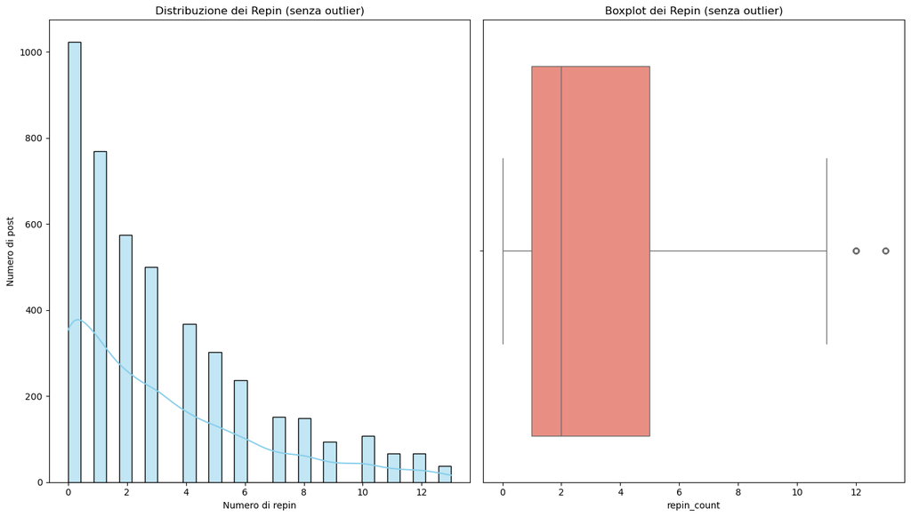

```python
#Usiamo il dataset senza outlier
df_plot = df_senza_outlier.copy()

plt.figure(figsize=(14, 8))

#Subplot 1: Istogramma della distribuzione dei repin
plt.subplot(1, 2, 1)
sns.histplot(df_plot['repin_count'], bins=30, kde=True, color='skyblue')
plt.title('Distribuzione dei Repin (senza outlier)')
plt.xlabel('Numero di repin')
plt.ylabel('Numero di post')

#Subplot 2: Boxplot per identificare visivamente eventuali anomalie residue
plt.subplot(1, 2, 2)
sns.boxplot(x=df_plot['repin_count'], color='salmon')
plt.title('Boxplot dei Repin (senza outlier)')

plt.tight_layout()
plt.show()
```

La distribuzione del numero di **repin** mostra un'elevata **asimmetria positiva**: la maggior parte dei post riceve pochi repin, mentre solo una piccola parte ottiene valori più alti.

L’**istogramma** evidenzia una tipica distribuzione a **“coda lunga”**, frequente nei contenuti social, in cui pochi post raggiungono un alto livello di diffusione.

Anche dopo la **rimozione degli outlier** più estremi (secondo il criterio **IQR**), il **boxplot** evidenzia ancora la presenza di **valori atipici**. Questo accade perché il boxplot ricalcola i **quartili** e l’**intervallo interquartile (IQR)** sul nuovo sottoinsieme di dati, che ha una distribuzione più compatta: di conseguenza, l’**IQR** si restringe e alcuni valori che precedentemente erano considerati nella norma risultano ora **outlier** rispetto a questa nuova scala.

Il boxplot riflette quindi la forte **variabilità** nella **popolarità** dei contenuti, anche tra quelli apparentemente **“non estremi”**.

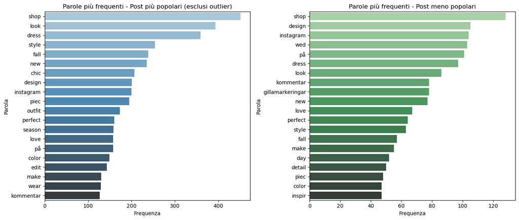

```python
#Funzione per ottenere le frequenze delle parole usando CountVectorizer
def ottieni_frequenze(df_group, max_features=100):
    vectorizer = CountVectorizer(max_features=max_features)
    X = vectorizer.fit_transform(df_group['stemmed'].fillna(''))
    frequenze = X.sum(axis=0).A1
    parole = vectorizer.get_feature_names_out()
    df_frequenze = pd.DataFrame({'Parola': parole, 'Frequenza': frequenze})
    return df_frequenze.sort_values(by='Frequenza', ascending=False).head(20)

#Otteniamo le 20 parole più frequenti per ciascun gruppo
df_top_popolari = ottieni_frequenze(gruppo_popolari)
df_top_meno_popolari = ottieni_frequenze(gruppo_meno_popolari)

plt.figure(figsize=(14, 6))

#Post più popolari
plt.subplot(1, 2, 1)
sns.barplot(
    y='Parola',
    x='Frequenza',
    hue='Parola',
    data=df_top_popolari,
    palette='Blues_d',
    legend=False
)
plt.title('Parole più frequenti - Post più popolari (esclusi outlier)')

#Post meno popolari
plt.subplot(1, 2, 2)
sns.barplot(
    y='Parola',
    x='Frequenza',
    hue='Parola',
    data=df_top_meno_popolari,
    palette='Greens_d',
    legend=False
)
plt.title('Parole più frequenti - Post meno popolari')

plt.tight_layout()
plt.show()
```

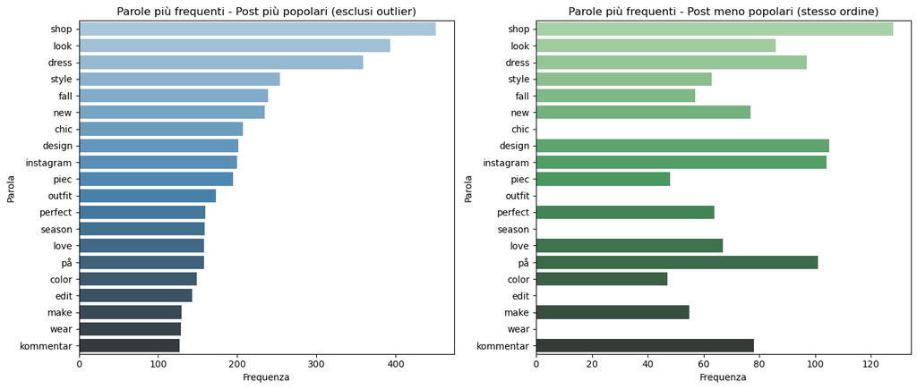

```
Confronto frequenze - Parole ordinate come nel primo grafico:
=================================================================
Pos Parola          Pop. Posts   Meno Pop.    Differenza
-----------------------------------------------------------------
1   shop            451          128          323
2   look            393          86           307
3   dress           359          97           262
4   style           254          63           191
5   fall            239          57           182
6   new             235          77           158
7   chic            207          0            207
8   design          201          105          96
9   instagram       200          104          96
10  piec            195          48           147
11  outfit          173          0            173
12  perfect         160          64           96
13  season          159          0            159
14  love            158          67           91
15  på              158          101          57
16  color           149          47           102
17  edit            143          0            143
18  make            130          55           75
19  wear            129          0            129
20  kommentar       127          78           49
-----------------------------------------------------------------
Parole con freq. 0 nei post meno popolari: 5
Parole presenti in entrambi i gruppi: 15
```

```python
#Estraiamo le parole del primo grafico nell'ordine corretto (dal più frequente al meno frequente)
parole_popolari_ordinate = df_top_popolari['Parola'].tolist()

#Creiamo un dizionario delle frequenze per i post meno popolari
freq_meno_popolari_dict = dict(zip(df_top_meno_popolari['Parola'], df_top_meno_popolari['Frequenza']))

#Adesso creiamo la lista delle frequenze per i post meno popolari seguendo l'ordine del primo grafico
frequenze_meno_pop_ordinate = []
for parola in parole_popolari_ordinate:
    if parola in freq_meno_popolari_dict:
        frequenze_meno_pop_ordinate.append(freq_meno_popolari_dict[parola])
    else:
        frequenze_meno_pop_ordinate.append(0)

#Poi generiamo il DataFrame per il secondo grafico con l'ordine corretto
df_meno_pop_ordinato = pd.DataFrame({
    'Parola': parole_popolari_ordinate,
    'Frequenza': frequenze_meno_pop_ordinate
})

#Visualizziamo i grafici
plt.figure(figsize=(14, 6))

#Post più popolari (grafico originale)
plt.subplot(1, 2, 1)
sns.barplot(
    y='Parola',
    x='Frequenza',
    hue='Parola',
    data=df_top_popolari,
    palette='Blues_d',
    legend=False
)
plt.title('Parole più frequenti - Post più popolari (esclusi outlier)')

#Post meno popolari (con ordine delle parole uguale al primo grafico)
plt.subplot(1, 2, 2)
sns.barplot(
    y='Parola',
    x='Frequenza',
    hue='Parola',
    data=df_meno_pop_ordinato,
    palette='Greens_d',
    legend=False
)
plt.title('Parole più frequenti - Post meno popolari (stesso ordine)')

plt.tight_layout()
plt.show()

#Stampiamo le statistiche per verifica
print("\nConfronto frequenze - Parole ordinate come nel primo grafico:")
print("=" * 65)
print(f"{'Pos':<3} {'Parola':<15} {'Pop. Posts':<12} {'Meno Pop.':<12} {'Differenza':<12}")
print("-" * 65)

for i, parola in enumerate(parole_popolari_ordinate):
    freq_pop = df_top_popolari[df_top_popolari['Parola'] == parola]['Frequenza'].iloc[0]
    freq_meno_pop = frequenze_meno_pop_ordinate[i]
    differenza = freq_pop - freq_meno_pop
    print(f"{i+1:<3} {parola:<15} {freq_pop:<12} {freq_meno_pop:<12} {differenza:<12}")

print("-" * 65)
print(f"Parole con freq. 0 nei post meno popolari: {sum(1 for x in frequenze_meno_pop_ordinate if x == 0)}")
print(f"Parole presenti in entrambi i gruppi: {sum(1 for x in frequenze_meno_pop_ordinate if x > 0)}")
```

Inizialmente abbiamo confrontato le **parole più frequenti nei post popolari e meno popolari**, ipotizzando di trovare differenze significative nel linguaggio utilizzato. Tuttavia, già da una prima analisi, abbiamo notato che molti termini si ripetevano in entrambi i grafici generati.

Per approfondire questa osservazione, abbiamo creato un confronto visuale diretto affiancando i due grafici: **"Parole più frequenti - Post più popolari (esclusi outlier)"** e **"Parole più frequenti - Post meno popolari (stesso ordine)"**. Questa visualizzazione parallela ci ha permesso di analizzare più efficacemente quali termini fossero comuni tra le due categorie e con quale frequenza.

Se, da questo primo confronto, volessimo estrarre dei punti chiave possiamo dire che:

Dopo aver analizzato i dati escludendo gli outlier, procediamo ora a verificare se emergono divergenze confrontando le **parole più frequenti nei post più popolari** - **includendo** questa volta anche gli **outlier** - con quelle dei **post meno popolari**.

```python
#Carichiamo gli outlier salvati in precedenza
outlier_df = pd.read_csv('outlier_repin.csv')

#Visualizziamo per verificarne la struttura
print(outlier_df.head(1))

#Aggiungiamo gli outlier al gruppo dei post più popolari
gruppo_popolari_aggiornato = pd.concat([gruppo_popolari, outlier_df], ignore_index=True)

print(f"\nNuovo numero di post popolari (inclusi outlier): {len(gruppo_popolari_aggiornato)}")
```

[output not shown]

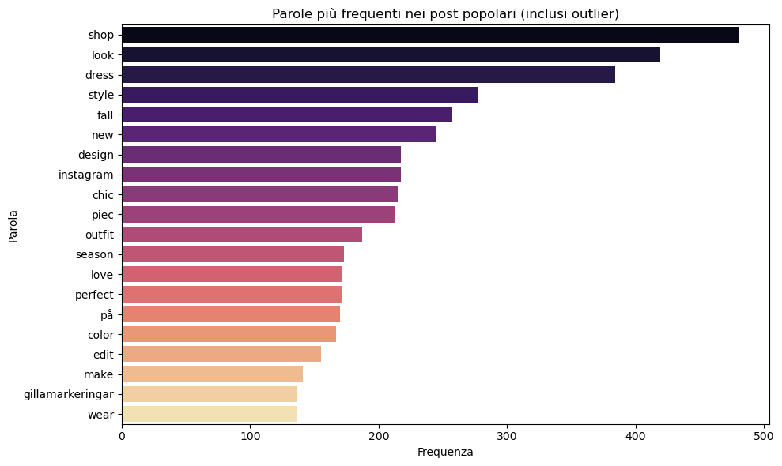

```python
#Ricarichiamo il dataset con gli outlier
outlier_df = pd.read_csv('outlier_repin.csv')

#Uniamo gli outlier al gruppo dei post più popolari
gruppo_popolari_aggiornato = pd.concat([gruppo_popolari, outlier_df], ignore_index=True)

#Analizziamo la frequenza delle parole con CountVectorizer
vectorizer = CountVectorizer()
X = vectorizer.fit_transform(gruppo_popolari_aggiornato['stemmed'])

#Sommiamo le occorrenze delle parole
word_freq = X.sum(axis=0).A1
parole = vectorizer.get_feature_names_out()
df_top_parole = pd.DataFrame({'Parola': parole, 'Frequenza': word_freq})
df_top_parole = df_top_parole.sort_values(by='Frequenza', ascending=False).head(20)

#Visualizziamo:
plt.figure(figsize=(10, 6))
sns.barplot(
    data=df_top_parole,
    y='Parola',
    x='Frequenza',
    hue='Parola',
    palette='magma',
    legend=False
)
plt.title('Parole più frequenti nei post popolari (inclusi outlier)')
plt.xlabel('Frequenza')
plt.ylabel('Parola')
plt.tight_layout()
plt.show()
```

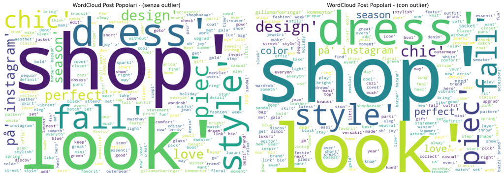

```python
def testo_unito(df):
    return ' '.join(df['stemmed'].dropna())

#Testo prima dell'aggiunta outlier
testo_prima = testo_unito(gruppo_popolari)

#Testo dopo reinserimento outlier
testo_dopo = testo_unito(gruppo_popolari_aggiornato)

#Generiamo WordCloud
wc_prima = WordCloud(width=600, height=400, background_color='white').generate(testo_prima)
wc_dopo = WordCloud(width=600, height=400, background_color='white').generate(testo_dopo)

#Visualizzazione affiancata:
plt.figure(figsize=(16, 7))

plt.subplot(1, 2, 1)
plt.imshow(wc_prima, interpolation='bilinear')
plt.title('WordCloud Post Popolari - (senza outlier)')
plt.axis('off')

plt.subplot(1, 2, 2)
plt.imshow(wc_dopo, interpolation='bilinear')
plt.title('WordCloud Post Popolari - (con outlier)')
plt.axis('off')

plt.tight_layout()
plt.show()
```

Prima di procedere con il confronto tra le **parole più frequenti nei post popolari (inclusi gli outlier)** e **quelle dei post meno popolari**, abbiamo creato una **visualizzazione** attraverso due wordcloud che mostrano:

- **WordCloud Post Popolari** *(senza outlier)*
- **WordCloud Post Popolari** *(con outlier)*

Dall'analisi visuale dei due wordcloud emerge chiaramente che le **parole dominanti** rimangono sostanzialmente **identiche** in entrambe le rappresentazioni:

- **look** - appare come termine centrale in entrambi i grafici;
- **shop** - mantiene una posizione di rilievo costante;
- **dress** - conserva dimensioni significative;
- **style** - rimane tra le parole più frequenti;
- **fall** - si conferma come termine ricorrente.

La **similarità** tra i due wordcloud indica che gli **outlier** non introducono variazioni sostanziali nel vocabolario dominante dei post popolari. Questa osservazione ci porta a **ipotizzare** che il confronto con i post meno popolari non rivelerà differenze drastiche nel vocabolario di base. Tuttavia, potrebbero emergere **sfumature interessanti** nelle frequenze relative e nella presenza di termini specifici che caratterizzano i contenuti.

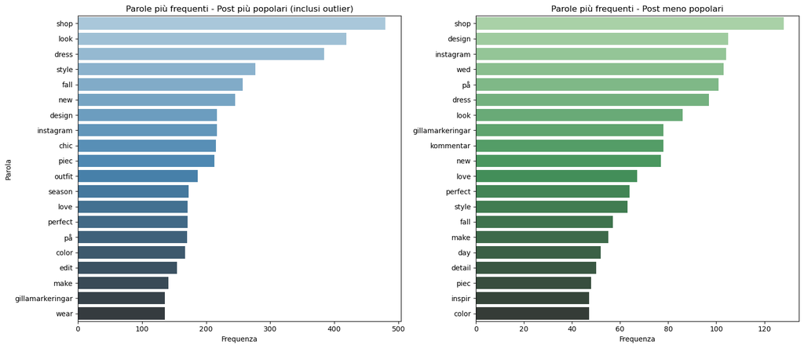

```python
def calcola_frequenze(df_group, colonna_testo='stemmed', top_n=20):
    vectorizer = CountVectorizer()
    X = vectorizer.fit_transform(df_group[colonna_testo].dropna())
    parole = vectorizer.get_feature_names_out()
    frequenze = X.sum(axis=0).A1
    df_freq = pd.DataFrame({'Parola': parole, 'Frequenza': frequenze})
    df_freq = df_freq.sort_values(by='Frequenza', ascending=False).head(top_n)
    return df_freq

freq_popolari_aggiornati = calcola_frequenze(gruppo_popolari_aggiornato)
freq_meno_popolari = calcola_frequenze(gruppo_meno_popolari)

plt.figure(figsize=(16, 7))

plt.subplot(1, 2, 1)
sns.barplot(
    data=freq_popolari_aggiornati,
    y='Parola',
    x='Frequenza',
    hue='Parola',
    palette='Blues_d',
    dodge=False,
    legend=False
)
plt.title('Parole più frequenti - Post più popolari (inclusi outlier)')
plt.xlabel('Frequenza')
plt.ylabel('Parola')

plt.subplot(1, 2, 2)
sns.barplot(
    data=freq_meno_popolari,
    y='Parola',
    x='Frequenza',
    hue='Parola',
    palette='Greens_d',
    dodge=False,
    legend=False
)
plt.title('Parole più frequenti - Post meno popolari')
plt.xlabel('Frequenza')
plt.ylabel('')

plt.tight_layout()
plt.show()
```

Dal confronto tra i grafici **"Parole più frequenti - Post più popolari (inclusi outlier)"** e **"Parole più frequenti - Post meno popolari"**, emerge un dato interessante: nei post meno popolari si riscontra una maggiore presenza di termini in **lingua scandinava** rispetto a quelli presenti nel grafico dei post più popolari. Tra questi, spiccano parole come:

- **"på"** (preposizione svedese)
- **"gillamarkeringar"** (like/mi piace in svedese)
- **"kommentar"** (commento in svedese)
- **"wed"**, che compare frequentemente nei post meno popolari, ma è del tutto assente tra i termini più ricorrenti nei post più performanti.

- **Limitare** la portata potenziale dei contenuti;
- **Ridurre** l’engagement complessivo;
- **Ostacolare** la viralità a livello internazionale.

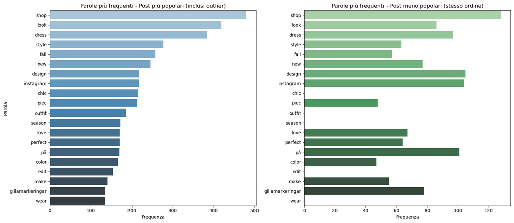

```
Confronto frequenze - Parole ordinate come nel primo grafico:
======================================================================
Pos Parola          Pop. Posts   Meno Pop.    Differenza
----------------------------------------------------------------------
1   shop            480          128          352
2   look            419          86           333
3   dress           384          97           287
4   style           277          63           214
5   fall            257          57           200
6   new             245          77           168
7   design          217          105          112
8   instagram       217          104          113
9   chic            215          0            215
10  piec            213          48           165
11  outfit          187          0            187
12  season          173          0            173
13  love            171          67           104
14  perfect         171          64           107
15  på              170          101          69
16  color           167          47           120
17  edit            155          0            155
18  make            141          55           86
19  gillamarkeringar 136          78           58
20  wear            136          0            136
----------------------------------------------------------------------
Parole con freq. 0 nei post meno popolari: 5
Parole presenti in entrambi i gruppi: 15

Frequenza totale post popolari (top 20): 4531
Frequenza totale post meno popolari (stesse parole): 1177
Rapporto frequenze (Pop/Meno Pop): 3.85
```

```python
#Estraiamo le parole del primo grafico nell'ordine corretto (dal più frequente al meno frequente)
parole_popolari_ordinate = freq_popolari_aggiornati['Parola'].tolist()

#Creiamo un dizionario delle frequenze per i post meno popolari
freq_meno_popolari_dict = dict(zip(freq_meno_popolari['Parola'], freq_meno_popolari['Frequenza']))

#Poi creiamo la lista delle frequenze per i post meno popolari seguendo l'ordine del primo grafico
frequenze_meno_pop_ordinate = []
for parola in parole_popolari_ordinate:
    if parola in freq_meno_popolari_dict:
        frequenze_meno_pop_ordinate.append(freq_meno_popolari_dict[parola])
    else:
        frequenze_meno_pop_ordinate.append(0)

#Adesso creiamo il DataFrame per il secondo grafico con l'ordine corretto
freq_meno_pop_ordinato = pd.DataFrame({
    'Parola': parole_popolari_ordinate,
    'Frequenza': frequenze_meno_pop_ordinate
})

#Visualizziamo i grafici
plt.figure(figsize=(16, 7))

#Post più popolari (inclusi outlier)
plt.subplot(1, 2, 1)
sns.barplot(
    data=freq_popolari_aggiornati,
    y='Parola',
    x='Frequenza',
    hue='Parola',
    palette='Blues_d',
    dodge=False,
    legend=False
)
plt.title('Parole più frequenti - Post più popolari (inclusi outlier)')
plt.xlabel('Frequenza')
plt.ylabel('Parola')

#Post meno popolari (con ordine delle parole uguale al primo grafico)
plt.subplot(1, 2, 2)
sns.barplot(
    data=freq_meno_pop_ordinato,
    y='Parola',
    x='Frequenza',
    hue='Parola',
    palette='Greens_d',
    dodge=False,
    legend=False
)
plt.title('Parole più frequenti - Post meno popolari (stesso ordine)')
plt.xlabel('Frequenza')
plt.ylabel('')

plt.tight_layout()
plt.show()

#Stampiamo le statistiche per verifica
print("\nConfronto frequenze - Parole ordinate come nel primo grafico:")
print("=" * 70)
print(f"{'Pos':<3} {'Parola':<15} {'Pop. Posts':<12} {'Meno Pop.':<12} {'Differenza':<12}")
print("-" * 70)

for i, parola in enumerate(parole_popolari_ordinate):
    freq_pop = freq_popolari_aggiornati[freq_popolari_aggiornati['Parola'] == parola]['Frequenza'].iloc[0]
    freq_meno_pop = frequenze_meno_pop_ordinate[i]
    differenza = freq_pop - freq_meno_pop
    print(f"{i+1:<3} {parola:<15} {freq_pop:<12} {freq_meno_pop:<12} {differenza:<12}")

print("-" * 70)
print(f"Parole con freq. 0 nei post meno popolari: {sum(1 for x in frequenze_meno_pop_ordinate if x == 0)}")
print(f"Parole presenti in entrambi i gruppi: {sum(1 for x in frequenze_meno_pop_ordinate if x > 0)}")

#Statistiche aggiuntive
total_freq_pop = freq_popolari_aggiornati['Frequenza'].sum()
total_freq_meno_pop = sum(frequenze_meno_pop_ordinate)
print(f"\nFrequenza totale post popolari (top 20): {total_freq_pop}")
print(f"Frequenza totale post meno popolari (stesse parole): {total_freq_meno_pop}")
print(f"Rapporto frequenze (Pop/Meno Pop): {total_freq_pop/total_freq_meno_pop:.2f}" if total_freq_meno_pop > 0 else "Rapporto: infinito")
```

### Conclusioni

Di conseguenza, per rispondere alla domanda *"Cosa può migliorare la **performance** dei post su Pinterest?"*, si può affermare che è utile adottare uno stile comunicativo fondato su:

- Un utilizzo mirato di **keyword settoriali**, in particolare legate al mondo della moda;
- La scelta dell’**inglese** come lingua principale per la diffusione dei contenuti.

### Referenze

- [Pinterest](https://it.pinterest.com/)
- [Developers Pinterest](https://developers.pinterest.com/)
- [Anaconda](https://www.anaconda.com/docs/)
- [NLTK](https://www.nltk.org/data.html)